# NaturalLanguageProcessingBasics

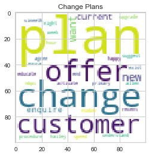

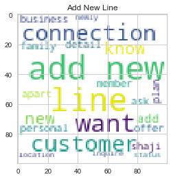

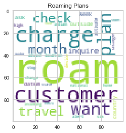

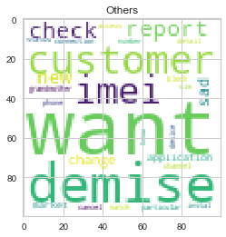

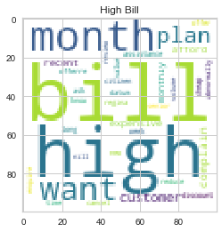

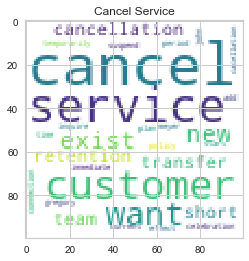

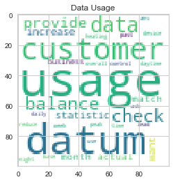

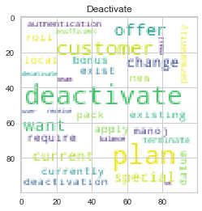

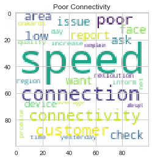

[figure not shown]

```python
for topic in uniqueTopics:
    wordCloudGenerator(df, topic) #,save = True , if you want to save the Word Clouds
```

Feature extractions

```python
lbl_enc = preprocessing.LabelEncoder()
y = lbl_enc.fit_transform(df[agentAssignedColumn].values)
X_train, X_test, y_train, y_test = train_test_split(df[commentTextColumn].values, y,stratify=y,random_state=42, test_size=0.1)
```

Tf-idf

```python
tfidf = TfidfVectorizer(strip_accents='unicode', analyzer='word',token_pattern=r'\w{1,}',ngram_range=(1, 3),use_idf=True,smooth_idf=True,sublinear_tf=True,stop_words = 'english')
# Fit and transform Tf-idf to both training and test sets
tfidf.fit(list(X_train) + list(X_test))
X_train_tfidf =  tfidf.transform(X_train)
X_test_tfidf = tfidf.transform(X_test)
```

Bag of Words

```python
countvec = CountVectorizer(analyzer='word',token_pattern=r'\w{1,}',ngram_range=(1, 3), stop_words = 'english', binary=True)
# Fit and transform CountVectorizer to both training and test sets
countvec.fit(list(X_train) + list(X_test))
X_train_countvec =  countvec.transform(X_train)
X_test_countvec = countvec.transform(X_test)
```

# Text Classification - Supervised Approach

Now that we have cleaned text and its corresponding labels, we can start modelling step. First we use a `Supervised Learning` approach. The methods we use in this approach are:

- [Logistic Regression](https://en.wikipedia.org/wiki/Logistic_regression): We use a pipeline approach of both [Count Vectorizer](https://en.wikipedia.org/wiki/Bag-of-words_model) and [TF-IDF Vectorizer](https://en.wikipedia.org/wiki/Tf%E2%80%93idf).
- [Naive Bayes](https://en.wikipedia.org/wiki/Naive_Bayes_classifier): Here also, we use a pipeline approach of both [Count Vectorizer](https://en.wikipedia.org/wiki/Bag-of-words_model) and [TF-IDF Vectorizer](https://en.wikipedia.org/wiki/Tf%E2%80%93idf).
- [Stochastic Gradient Descent](https://en.wikipedia.org/wiki/Stochastic_gradient_descent): We use a pipeline approach of both [Count Vectorizer](https://en.wikipedia.org/wiki/Bag-of-words_model) and [TF-IDF Vectorizer](https://en.wikipedia.org/wiki/Tf%E2%80%93idf).
- [Random Forest Classifier](https://en.wikipedia.org/wiki/Random_forest) : Here also, we use a pipeline approach of both [Count Vectorizer](https://en.wikipedia.org/wiki/Bag-of-words_model) and [TF-IDF Vectorizer](https://en.wikipedia.org/wiki/Tf%E2%80%93idf).
- [XGBoost Classifier](https://en.wikipedia.org/wiki/Gradient_boosting): We use a pipeline approach of both [Count Vectorizer](https://en.wikipedia.org/wiki/Bag-of-words_model) and [TF-IDF Vectorizer](https://en.wikipedia.org/wiki/Tf%E2%80%93idf).
- [Support Vector Machines(SVC)](https://en.wikipedia.org/wiki/Support-vector_machine) : Here also, we use a pipeline approach of both [Count Vectorizer](https://en.wikipedia.org/wiki/Bag-of-words_model) and [TF-IDF Vectorizer](https://en.wikipedia.org/wiki/Tf%E2%80%93idf).
- Combination of [Word2Vec](https://en.wikipedia.org/wiki/Word2vec) & Logistic Regression: For using this, you'll need to download the file `GoogleNews-vectors-negative300.bin.gz` from [this location](https://code.google.com/archive/p/word2vec/)
- Combination of [Doc2Vec](https://markroxor.github.io/gensim/static/notebooks/doc2vec-wikipedia.html) & Logistic Regression: Refer [this link](https://medium.com/scaleabout/a-gentle-introduction-to-doc2vec-db3e8c0cce5e) for a better understanding.
- Bag-Of-Words with Keras Sequential Model
- [LSTM](https://en.wikipedia.org/wiki/Long_short-term_memory)
- Heuristic/Rule Based Approach.

```python
print("Total Number of Words in the column "+commentTextColumn+" is "+str(df[commentTextColumn].apply(lambda x: len(x.split(' '))).sum()))
```

```
Total Number of Words in the column CustomerInteractionText is 608
```

```python
X = df[commentTextColumn]
y = df[agentAssignedColumn]
X_train, X_test, y_train, y_test = train_test_split(X, y, test_size=0.3, random_state = 30)
```

## Logistic Regression

```python
%time
logreg = Pipeline([('vect', CountVectorizer()),('tfidf', TfidfTransformer()),('clf', LogisticRegression(n_jobs=1, C=1e5)),])
logreg.fit(X_train, y_train)
y_pred = logreg.predict(X_test)

print('accuracy %s' % accuracy_score(y_pred, y_test))
print(classification_report(y_test, y_pred,target_names=uniqueTopics))
```

```
Wall time: 0 ns
accuracy 0.8387096774193549
                   precision    recall  f1-score   support

           Others       1.00      1.00      1.00         4
   Cancel Service       0.75      0.60      0.67         5
Poor Connectivity       1.00      1.00      1.00         4
     Add New Line       1.00      1.00      1.00         2
         Port Out       1.00      1.00      1.00         1
        High Bill       0.67      1.00      0.80         2
       Deactivate       0.75      0.75      0.75         4
     Change Plans       0.67      1.00      0.80         2
    Roaming Plans       0.50      0.33      0.40         3
       Data Usage       1.00      1.00      1.00         4

         accuracy                           0.84        31
        macro avg       0.83      0.87      0.84        31
     weighted avg       0.84      0.84      0.83        31
```

## Naive Bayes

```python
%time
nb = Pipeline([('vect', CountVectorizer()),('tfidf', TfidfTransformer()),('clf', MultinomialNB(alpha=0.01)),])
nb.fit(X_train, y_train)
y_pred = nb.predict(X_test)

print('accuracy %s' % accuracy_score(y_pred, y_test))
print(classification_report(y_test, y_pred,target_names=uniqueTopics))
```

```
Wall time: 0 ns
accuracy 0.8064516129032258
                   precision    recall  f1-score   support

           Others       0.80      1.00      0.89         4
   Cancel Service       0.75      0.60      0.67         5
Poor Connectivity       1.00      1.00      1.00         4
     Add New Line       1.00      0.50      0.67         2
         Port Out       1.00      1.00      1.00         1
        High Bill       0.67      1.00      0.80         2
       Deactivate       1.00      0.75      0.86         4
     Change Plans       0.67      1.00      0.80         2
    Roaming Plans       0.50      0.33      0.40         3
       Data Usage       0.80      1.00      0.89         4

         accuracy                           0.81        31
        macro avg       0.82      0.82      0.80        31
     weighted avg       0.82      0.81      0.79        31
```

## Stochastic Gradient Descent

```python
%time
sgd = Pipeline([('vect', CountVectorizer()),('tfidf', TfidfTransformer()),('clf', SGDClassifier(loss='hinge', penalty='l2',alpha=1e-2, random_state=42, max_iter=5, tol=None)),])
sgd.fit(X_train, y_train)

y_pred = sgd.predict(X_test)

print('accuracy %s' % accuracy_score(y_pred, y_test))
print(classification_report(y_test, y_pred,target_names=uniqueTopics))
```

```
Wall time: 0 ns
accuracy 0.8064516129032258
                   precision    recall  f1-score   support

           Others       0.80      1.00      0.89         4
   Cancel Service       1.00      0.40      0.57         5
Poor Connectivity       1.00      1.00      1.00         4
     Add New Line       0.67      1.00      0.80         2
         Port Out       1.00      1.00      1.00         1
        High Bill       0.67      1.00      0.80         2
       Deactivate       1.00      0.75      0.86         4
     Change Plans       0.67      1.00      0.80         2
    Roaming Plans       0.50      0.33      0.40         3
       Data Usage       0.80      1.00      0.89         4

         accuracy                           0.81        31
        macro avg       0.81      0.85      0.80        31
     weighted avg       0.84      0.81      0.79        31
```

## Random Forest

```python
forest = Pipeline([('vect', CountVectorizer()),('tfidf', TfidfTransformer()),('clf', RandomForestClassifier(max_features='sqrt',n_estimators=1000, max_depth=3,random_state=0)),])
forest.fit(X_train, y_train)
y_pred = forest.predict(X_test)

print('accuracy %s' % accuracy_score(y_pred, y_test))
print(classification_report(y_test, y_pred,target_names=uniqueTopics))
```

```
accuracy 0.8064516129032258
                   precision    recall  f1-score   support

           Others       1.00      1.00      1.00         4
   Cancel Service       1.00      0.60      0.75         5
Poor Connectivity       1.00      1.00      1.00         4
     Add New Line       0.67      1.00      0.80         2
         Port Out       0.50      1.00      0.67         1
        High Bill       0.33      0.50      0.40         2
       Deactivate       0.80      1.00      0.89         4
     Change Plans       1.00      1.00      1.00         2
    Roaming Plans       0.50      0.33      0.40         3
       Data Usage       1.00      0.75      0.86         4

         accuracy                           0.81        31
        macro avg       0.78      0.82      0.78        31
     weighted avg       0.85      0.81      0.81        31
```

## XGBoost

```python
xgboost = Pipeline([('vect', CountVectorizer()),('tfidf', TfidfTransformer()),('clf', xgb.XGBClassifier(n_jobs=1,max_depth=3,learning_rate=0.01,n_estimators=1000)),])
xgboost.fit(X_train, y_train)
y_pred = xgboost.predict(X_test)

print('accuracy %s' % accuracy_score(y_pred, y_test))
print(classification_report(y_test, y_pred,target_names=uniqueTopics))
```

```
accuracy 0.7096774193548387
                   precision    recall  f1-score   support

           Others       1.00      1.00      1.00         4
   Cancel Service       1.00      0.60      0.75         5
Poor Connectivity       1.00      0.50      0.67         4
     Add New Line       1.00      1.00      1.00         2
         Port Out       0.14      1.00      0.25         1
        High Bill       0.50      0.50      0.50         2
       Deactivate       0.60      0.75      0.67         4
     Change Plans       1.00      0.50      0.67         2
    Roaming Plans       1.00      0.33      0.50         3
       Data Usage       1.00      1.00      1.00         4

         accuracy                           0.71        31
        macro avg       0.82      0.72      0.70        31
     weighted avg       0.89      0.71      0.75        31
```

## Support Vector Machines(SVM)

```python
%time

svc = Pipeline([('vect', CountVectorizer()),('tfidf', TfidfTransformer()),('clf', SVC(gamma='scale', decision_function_shape='ovo'))])
svc.fit(X_train, y_train)
y_pred = svc.predict(X_test)

print('accuracy %s' % accuracy_score(y_pred, y_test))
print(classification_report(y_test, y_pred,target_names=uniqueTopics))
```

[output not shown]

Checking the misclassified

```python
#Evaluating Logistic Regression, since it has comparatevely better accuracy(83%)
logregclf = LogisticRegression(n_jobs=1, C=0.5)
logregclf.fit(X_train_tfidf, y_train)
y_pred = logregclf.predict(X_test_tfidf)
print("---Misclassified Examples---")
for x, y, y_hat in zip(X_test, lbl_enc.inverse_transform(y_test), lbl_enc.inverse_transform(y_pred)):
    if y != y_hat:
        print(f'Cleaned Comment: {x} | Original Topic: {y} | Predicted Topic: {y_hat}')
```

```
---Misclassified Examples---
Cleaned Comment: customer deactivate onam offer receive email sm | Original Topic: Deactivate | Predicted Topic: Change Plans
Cleaned Comment: port high bill datum plan | Original Topic: Port Out | Predicted Topic: High Bill
```

Learning Curve of the Model

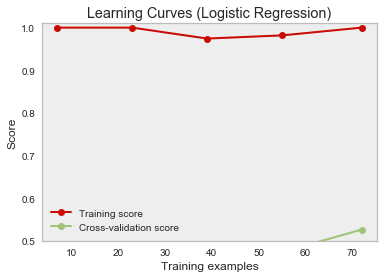

```python
def plot_learning_curve(estimator, title, X, y, ylim=None, cv=None, n_jobs=None, train_sizes=np.linspace(.1, 1.0, 5)):
    plt.figure()
    plt.title(title)
    if ylim is not None:
        plt.ylim(*ylim)
    plt.xlabel("Training examples")
    plt.ylabel("Score")
    train_sizes, train_scores, test_scores = learning_curve(
        estimator, X, y, cv=cv, n_jobs=n_jobs, train_sizes=train_sizes)
    train_scores_mean = np.mean(train_scores, axis=1)
    train_scores_std = np.std(train_scores, axis=1)
    test_scores_mean = np.mean(test_scores, axis=1)
    test_scores_std = np.std(test_scores, axis=1)
    plt.grid()

    plt.fill_between(train_sizes, train_scores_mean - train_scores_std,
                     train_scores_mean + train_scores_std, alpha=0.1,
                     color="r")
    plt.fill_between(train_sizes, test_scores_mean - test_scores_std,
                     test_scores_mean + test_scores_std, alpha=0.1, color="g")
    plt.plot(train_sizes, train_scores_mean, 'o-', color="r",
             label="Training score")
    plt.plot(train_sizes, test_scores_mean, 'o-', color="g",
             label="Cross-validation score")

    plt.legend(loc="best")
    return plt
X, y = X_train_tfidf, y_train
title = "Learning Curves (Logistic Regression)"
# SVC is more expensive so we do a lower number of CV iterations:
cv = ShuffleSplit(n_splits=1, test_size=0.2, random_state=0)
estimator = LogisticRegression()
plot_learning_curve(estimator, title, X, y, (0.5, 1.01), cv=cv, n_jobs=10)
plt.show();
```

## Combining Word2Vec & Logistic Regression

```python
%time
wv = gensim.models.KeyedVectors.load_word2vec_format("GoogleNews-vectors-negative300.bin.gz", binary=True)
wv.init_sims(replace=True)
list(islice(wv.vocab, 13030, 13050))
```

```python
# The common way is to average the two word vectors. BOW based approaches which includes averaging.
def word_averaging(wv, words):
    all_words, mean = set(), []

    for word in words:
        if isinstance(word, np.ndarray):
            mean.append(word)
        elif word in wv.vocab:
            mean.append(wv.syn0norm[wv.vocab[word].index])
            all_words.add(wv.vocab[word].index)

    if not mean:
        logging.warning("cannot compute similarity with no input %s", words)
        # FIXME: remove these examples in pre-processing
        return np.zeros(wv.vector_size,)

    mean = gensim.matutils.unitvec(np.array(mean).mean(axis=0)).astype(np.float32)
    return mean

def  word_averaging_list(wv, text_list):
    return np.vstack([word_averaging(wv, post) for post in text_list ])

def w2v_tokenize_text(text):
    tokens = []
    for sent in nltk.sent_tokenize(text, language='english'):
        for word in nltk.word_tokenize(sent, language='english'):
            if len(word) < 2:
                continue
            tokens.append(word)
    return tokens
```

```python
train, test = train_test_split(df, test_size=0.3, random_state = 42)

test_tokenized = test.apply(lambda r: w2v_tokenize_text(r[commentTextColumn]), axis=1).values
train_tokenized = train.apply(lambda r: w2v_tokenize_text(r[commentTextColumn]), axis=1).values

X_train_word_average = word_averaging_list(wv,train_tokenized)
X_test_word_average = word_averaging_list(wv,test_tokenized)
```

```python
%time
logreg = LogisticRegression(n_jobs=1, C=1e5)
logreg = logreg.fit(X_train_word_average, train[agentAssignedColumn])
y_pred = logreg.predict(X_test_word_average)

print('accuracy %s' % accuracy_score(y_pred, test[agentAssignedColumn]))
print(classification_report(test[agentAssignedColumn], y_pred,target_names=uniqueTopics))
```

[output not shown]

```
Wall time: 0 ns
```

## Combining Doc2Vec & Logistic Regression

```python
# Doc2vec, taking the linear combination of every term in the document creates a random walk with bias process in the word2vec space.
def label_sentences(corpus, label_type):
    """
    Gensim's Doc2Vec implementation requires each document/paragraph to have a label associated with it.
    We do this by using the TaggedDocument method. The format will be "TRAIN_i" or "TEST_i" where "i" is
    a dummy index of the post.
    """
    labeled = []
    for i, v in enumerate(corpus):
        label = label_type + '_' + str(i)
        labeled.append(TaggedDocument(v.split(), [label]))
    return labeled
```

```python
X_train, X_test, y_train, y_test = train_test_split(df[commentTextColumn], df[agentAssignedColumn], random_state=0, test_size=0.3)
X_train = label_sentences(X_train, 'Train')
X_test = label_sentences(X_test, 'Test')

all_data = X_train + X_test
all_data[:2]
```

```
[TaggedDocument(words=['gregory', 'cancel', 'service', 'temporarily'], tags=['Train_0']),
 TaggedDocument(words=['customer', 'ask', 'data', 'usage', 'past', 'week'], tags=['Train_1'])]
```

```python
model_dbow = Doc2Vec(dm=0, vector_size=300, negative=5, min_count=1, alpha=0.065, min_alpha=0.065)
model_dbow.build_vocab([x for x in tqdm(all_data)])

for epoch in range(30):
    model_dbow.train(utils.shuffle([x for x in tqdm(all_data)]), total_examples=len(all_data), epochs=1)
    model_dbow.alpha -= 0.002
    model_dbow.min_alpha = model_dbow.alpha
```

[output not shown]

```python
def get_vectors(model, corpus_size, vectors_size, vectors_type):
    """
    Get vectors from trained doc2vec model
    :param doc2vec_model: Trained Doc2Vec model
    :param corpus_size: Size of the data
    :param vectors_size: Size of the embedding vectors
    :param vectors_type: Training or Testing vectors
    :return: list of vectors
    """
    vectors = np.zeros((corpus_size, vectors_size))
    for i in range(0, corpus_size):
        prefix = vectors_type + '_' + str(i)
        vectors[i] = model.docvecs[prefix]
    return vectors

train_vectors_dbow = get_vectors(model_dbow, len(X_train), 300, 'Train')
test_vectors_dbow = get_vectors(model_dbow, len(X_test), 300, 'Test')

logreg = LogisticRegression(n_jobs=1, C=1e9)
logreg = logreg.fit(train_vectors_dbow, y_train)
y_pred = logreg.predict(test_vectors_dbow)

print('accuracy %s' % accuracy_score(y_pred, y_test))
print(classification_report(y_test, y_pred,target_names=uniqueTopics))
```

```
accuracy 0.43333333333333335
                   precision    recall  f1-score   support

           Others       0.50      1.00      0.67         3
   Cancel Service       0.50      0.50      0.50         2
Poor Connectivity       0.00      0.00      0.00         1
     Add New Line       1.00      0.67      0.80         3
         Port Out       0.50      0.20      0.29         5
        High Bill       0.50      0.20      0.29         5
       Deactivate       0.00      0.00      0.00         3
     Change Plans       0.33      0.50      0.40         2
    Roaming Plans       0.29      1.00      0.44         2
       Data Usage       0.67      0.50      0.57         4

         accuracy                           0.43        30
        macro avg       0.43      0.46      0.40        30
     weighted avg       0.48      0.43      0.41        30
```

## Bag-Of-Words with Keras

```python
train_size = int(len(df) * .7)
print ("Train size: %d" % train_size)
print ("Test size: %d" % (len(df) - train_size))

train_comments = df[commentTextColumn][:train_size]
train_topics = df[agentAssignedColumn][:train_size]

test_comments = df[commentTextColumn][train_size:]
test_topics = df[agentAssignedColumn][train_size:]

max_words = 500
tokenize = text.Tokenizer(num_words=max_words, char_level=False)
```

```
Train size: 70
Test size: 30
```

```python
%time
tokenize.fit_on_texts(train_comments) # only fit on train
x_train = tokenize.texts_to_matrix(train_comments)
x_test = tokenize.texts_to_matrix(test_comments)

encoder = LabelEncoder()
encoder.fit(train_topics)
y_train = encoder.transform(train_topics)
y_test = encoder.transform(test_topics)

num_classes = np.max(y_train) + 1
y_train = utils.to_categorical(y_train, num_classes)
y_test = utils.to_categorical(y_test, num_classes)

print('x_train shape:', x_train.shape)
print('x_test shape:', x_test.shape)
print('y_train shape:', y_train.shape)
print('y_test shape:', y_test.shape)
```

```
Wall time: 0 ns
x_train shape: (70, 500)
x_test shape: (30, 500)
y_train shape: (70, 10)
y_test shape: (30, 10)
```

```python
batch_size = 10
epochs = 10

# Build the model
model = Sequential()
model.add(Dense(512, input_shape=(max_words,)))
model.add(Activation('relu'))
model.add(Dropout(0.5))
model.add(Dense(num_classes))
model.add(Activation('softmax'))
model.compile(loss='categorical_crossentropy',optimizer='adam',metrics=['accuracy'])
history = model.fit(x_train, y_train, batch_size=batch_size, epochs=epochs, verbose=1, validation_split=0.1)

score = model.evaluate(x_test, y_test,batch_size=batch_size, verbose=1)
print('Test accuracy:', score[1])
```

```
Train on 63 samples, validate on 7 samples
Test accuracy: 0.7666666507720947
```

## LSTM

```python
# The maximum number of words to be used. (most frequent)
MAX_NB_WORDS = 500
# Max number of words in each complaint.
MAX_SEQUENCE_LENGTH = 15
# This is fixed.
EMBEDDING_DIM = 100

tokenizer = Tokenizer(num_words=MAX_NB_WORDS, filters='!"#$%&()*+,-./:;<=>?@[\]^_`{|}~', lower=True)
tokenizer.fit_on_texts(df[commentTextColumn].values)
word_index = tokenizer.word_index
print('Found %s unique tokens.' % len(word_index))

X = tokenizer.texts_to_sequences(df[commentTextColumn].values)
X = pad_sequences(X, maxlen=MAX_SEQUENCE_LENGTH)
print('Shape of data tensor:', X.shape)

Y = pd.get_dummies(df[agentAssignedColumn]).values
print('Shape of label tensor:', Y.shape)
```

```
Found 211 unique tokens.
Shape of data tensor: (100, 15)
Shape of label tensor: (100, 10)
```

```python
X_train, X_test, Y_train, Y_test = train_test_split(X,Y, test_size = 0.30, random_state = 42)
print(X_train.shape,Y_train.shape)
print(X_test.shape,Y_test.shape)
```

```
(70, 15) (70, 10)
(30, 15) (30, 10)
```

```python
# Build the model
model = Sequential()
model.add(Embedding(MAX_NB_WORDS, EMBEDDING_DIM, input_length=X.shape[1]))
model.add(SpatialDropout1D(0.2))
model.add(LSTM(100, dropout=0.2, recurrent_dropout=0.2))
model.add(Dense(10, activation='softmax'))
model.compile(loss='categorical_crossentropy', optimizer='adam', metrics=['accuracy'])
print(model.summary())
```

```
_________________________________________________________________
Layer (type)                 Output Shape              Param #
=================================================================
embedding_2 (Embedding)      (None, 15, 100)           50000
_________________________________________________________________
spatial_dropout1d_2 (Spatial (None, 15, 100)           0
_________________________________________________________________
lstm_2 (LSTM)                (None, 100)               80400
_________________________________________________________________
dense_10 (Dense)             (None, 10)                1010
=================================================================
Total params: 131,410
Trainable params: 131,410
Non-trainable params: 0
_________________________________________________________________
None
```

```python
epochs = 10
batch_size = 5

history = model.fit(X_train, Y_train, epochs=epochs, batch_size=batch_size,validation_split=0.1,callbacks=[EarlyStopping(monitor='val_loss', patience=3, min_delta=0.0001)])

accr = model.evaluate(X_test,Y_test)
print('Test set\n  Loss: {:0.3f}\n  Accuracy: {:0.3f}'.format(accr[0],accr[1]))
```

```
Train on 63 samples, validate on 7 samples
Test set
  Loss: 0.667
  Accuracy: 0.767
```

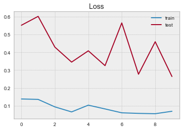

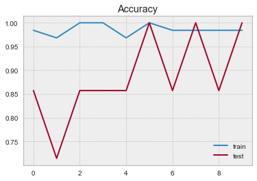

```python
plt.title('Loss')
plt.plot(history.history['loss'], label='train')
plt.plot(history.history['val_loss'], label='test')
plt.legend()
plt.show();

plt.title('Accuracy')
plt.plot(history.history['acc'], label='train')
plt.plot(history.history['val_acc'], label='test')
plt.legend()
plt.show();
```

Test with an unseen comment.

```python
new_complaint = ['Avinash want to cancel service.']
seq = tokenizer.texts_to_sequences(new_complaint)
padded = pad_sequences(seq, maxlen=MAX_SEQUENCE_LENGTH)
pred = model.predict(padded)
labels = uniqueTopics
print(pred, labels[np.argmax(pred)])
```

```
[[4.4254512e-03 9.2506969e-01 6.3394470e-04 2.0478480e-04 4.8004431e-03
  6.0026431e-03 1.3716313e-02 1.0041479e-02 3.2136165e-02 2.9691118e-03]] Cancel Service
```

## Heuristic/Rule Based Approach

```python
def removeFrequentOccuringWords(wordList):
    commonWords = ['customer', 'want', 'plan', 'month', 'new', 'inquire', 'check']
    wordList = [word for word in wordList if word not in commonWords]
    return ','.join(wordList)
```

```python
labelsKeywords = pd.DataFrame(columns = ['Label', 'Fuzzy Words', 'Strict Words'])

labelColumnList = list(df[agentAssignedColumn].value_counts().to_dict())
strictWordList = ['']
fuzzyWordList = ['']
for reasoncode in labelColumnList:
    fuzzyWordList.append(','.join(removeFrequentOccuringWords(wordFrequencyListPlot(reasoncode)).split(',')[-2:]))
    strictWordList.append(','.join(removeFrequentOccuringWords(wordFrequencyListPlot(reasoncode)).split(',')[:6]))

labelsKeywords['Label'] = ['Others'] + labelColumnList
labelsKeywords['Fuzzy Words'] = fuzzyWordList
labelsKeywords['Strict Words'] = strictWordList
labelsKeywords.head()
```

```
['speed', 'connection', 'connectivity', 'poor', 'customer', 'area', 'device', 'issue', 'low', 'face']
['speed', 'connection', 'connectivity', 'poor', 'customer', 'area', 'device', 'issue', 'low', 'face']
['port', 'customer', 'want', 'transfer', 'plan', 'service', 'ask', 'retain', 'porting', 'cancel']
['port', 'customer', 'want', 'transfer', 'plan', 'service', 'ask', 'retain', 'porting', 'cancel']
['cancel', 'service', 'customer', 'want', 'exist', 'new', 'plan', 'effect', 'celebration', 'add']
['cancel', 'service', 'customer', 'want', 'exist', 'new', 'plan', 'effect', 'celebration', 'add']
['usage', 'datum', 'customer', 'data', 'month', 'match', 'business', 'provide', 'balance', 'increase']
['usage', 'datum', 'customer', 'data', 'month', 'match', 'business', 'provide', 'balance', 'increase']
['bill', 'high', 'month', 'want', 'plan', 'customer', 'complain', 'monthly', 'afford', 'expensive']
['bill', 'high', 'month', 'want', 'plan', 'customer', 'complain', 'monthly', 'afford', 'expensive']
['roam', 'customer', 'charge', 'plan', 'want', 'month', 'check', 'travel', 'inquire', 'sim']
['roam', 'customer', 'charge', 'plan', 'want', 'month', 'check', 'travel', 'inquire', 'sim']
['plan', 'change', 'offer', 'want', 'new', 'customer', 'current', 'enquire', 'speed', 'extra']
['plan', 'change', 'offer', 'want', 'new', 'customer', 'current', 'enquire', 'speed', 'extra']
['want', 'imei', 'demise', 'customer', 'check', 'report', 'cancel', 'phone', 'instal', 'connection']
['want', 'imei', 'demise', 'customer', 'check', 'report', 'cancel', 'phone', 'instal', 'connection']
['plan', 'deactivate', 'customer', 'offer', 'want', 'change', 'current', 'special', 'insufficient', 'decativate']
['plan', 'deactivate', 'customer', 'offer', 'want', 'change', 'current', 'special', 'insufficient', 'decativate']
['new', 'add', 'line', 'want', 'connection', 'customer', 'know', 'plan', 'shaji', 'offer']
['new', 'add', 'line', 'want', 'connection', 'customer', 'know', 'plan', 'shaji', 'offer']
```

|  | Label | Fuzzy Words | Strict Words |
| --- | --- | --- | --- |
| 0 | Others |  |  |
| 1 | Poor Connectivity | low,face | speed,connection,connectivity,poor,area,device |
| 2 | Port Out | porting,cancel | port,transfer,service,ask,retain,porting |
| 3 | Cancel Service | celebration,add | cancel,service,exist,effect,celebration,add |
| 4 | Data Usage | balance,increase | usage,datum,data,match,business,provide |

```python
def find_best_label(TrainingWords, StrictWords, text_in):
    clnTxt = [st.stem(u.lower()) for u in  text_in.split()]
    if(len(clnTxt)==0):
        clnTxt =  'Others'
    NL = len(TrainingWords)
    probV = [0.0 for k in range(NL)]
    CM_A = []
    for j in range(NL):
        TrSet = set([ st.stem(u.lower())  for u in TrainingWords[j].split()])
        SWords = set([ u.lower().strip() for u in StrictWords[j].split(",")])  if len(StrictWords[j]) else []
        matching =  [s for s in SWords  if ((s in text_in) and len(set(s.split()).intersection(text_in.split()))==len(s.split())) ]
        cm = list(TrSet.intersection(clnTxt))
        if len(matching)>0:
            probV[j] = 1
            CM_A.append(matching)
            break
        else:
            if len(cm):
                CM_A.append(cm)
            else:
                CM_A.append([])
            probV[j] = (len(cm)/float(len(clnTxt)))
    return({'idx':np.argmax(probV), 'maxV':np.max(probV), 'wa':CM_A[np.argmax(probV)]})
```

```python
%time
TestData = df.copy()
test_buffer = TestData.iloc[:,1]

TrainingData = labelsKeywords.copy()

fuzzy_word_list = TrainingData['Fuzzy Words']
strict_word_list = TrainingData['Strict Words']
train_buffer = [fuzzy_word_list[i]+" "+strict_word_list[i] for i in range(len(TrainingData))]

Labels = [a for a in TrainingData['Label']]

TestData['New Topic'] = 0.0
TestData['Conf'] = 0.0
TestData['Matching words'] = ["" for i in range(len(TestData))]

for i in range(len(test_buffer)):
    BL = find_best_label(train_buffer, TrainingData['Strict Words'], test_buffer[i])
    TestData['New Topic'][i] = Labels[BL['idx']]
    TestData['Conf'][i] = BL['maxV']
    TestData['Matching words'][i] = ", ".join(BL['wa'])

TestData.head()
```

```
Wall time: 0 ns
```

|  | RecordID | CustomerInteractionRawText | AgentAssignedTopic | LocationID | CallDurationSeconds | AgentID | CustomerID | CustomerInteractionText | totalwords | language | New Topic | Conf | Matching words |
| --- | --- | --- | --- | --- | --- | --- | --- | --- | --- | --- | --- | --- | --- |
| 92 | 1890133 | Reported sad demise of customer. | Others | 2.0 | 19.0 | o6cXs | jD51a | report sad demise customer | 5 | en | Others | 1.0 | demise |
| 76 | 1890117 | Customer inquired about the cacellation policies. | Cancel Service | 0.0 | 13.0 | NvHk7 | 0Y5rx | customer inquire cacellation policy | 6 | en | Others | 0.0 |  |
| 11 | 1890052 | Low speed connection reported in Uppala area. | Poor Connectivity | 3.0 | 17.0 | eUYn2 | movRl | low speed connection report area | 7 | en | Poor Connectivity | 1.0 | speed, connection |
| 40 | 1890081 | 68347585642 want to add a new connection. | Add New Line | 3.0 | 14.0 | D3KmX | 8wxr3 | want add new connection | 7 | en | Cancel Service | 1.0 | add |
| 18 | 1890059 | Customer facing issues in connectivity from ye... | Poor Connectivity | 5.0 | 13.0 | 0mj3N | r34oU | customer face issue connectivity yesterday onw... | 10 | en | Poor Connectivity | 1.0 | connectivity |

```python
originalTopic = TestData[agentAssignedColumn]
newTopic = TestData['New Topic']

print('accuracy %s' % accuracy_score(newTopic, originalTopic))
print(classification_report(originalTopic, newTopic,target_names=uniqueTopics))
```

```
accuracy 0.57
                   precision    recall  f1-score   support

           Others       0.60      0.30      0.40        10
   Cancel Service       0.40      0.40      0.40        10
Poor Connectivity       0.70      0.70      0.70        10
     Add New Line       0.88      0.70      0.78        10
         Port Out       1.00      0.40      0.57        10
        High Bill       1.00      0.80      0.89        10
       Deactivate       0.26      0.80      0.39        10
     Change Plans       0.69      0.90      0.78        10
    Roaming Plans       0.64      0.70      0.67        10
       Data Usage       0.00      0.00      0.00        10

         accuracy                           0.57       100
        macro avg       0.62      0.57      0.56       100
     weighted avg       0.62      0.57      0.56       100
```

# Text Classification - Unsupervised Approach

We also try an `Unsupervised Learning` approach. [Latent Dirichlet allocation(LDA)](https://en.wikipedia.org/wiki/Latent_Dirichlet_allocation) is used to get the topic clusters. We use two types of Word Corpuses:

- Bag of Words
- TF-IDF

In trying to incorporate the context of sentences at times, we also try two word gram models:

- Unigram Word distribution
- Bigram Word distribution

## Topic Modelling using LDA

```python
#Gensim Preprocessing
def lemmatize_stemming(text):
    return stemmer.stem(WordNetLemmatizer().lemmatize(text, pos='v'))

def preprocess(text):
    result = []
    for token in gensim.utils.simple_preprocess(text):
        if token not in gensim.parsing.preprocessing.STOPWORDS and len(token) > 3:
            result.append(lemmatize_stemming(token))
    return result

processed_docs = df[commentTextColumn].map(preprocess)
processed_docs[:5]
```

```
92                              [report, demis, custom]
76                      [custom, inquir, cacel, polici]
11                       [speed, connect, report, area]
40                                      [want, connect]
18    [custom, face, issu, connect, yesterday, onwar...
Name: CustomerInteractionText, dtype: object
```

### LDA Using Bag-of-Words

- Unigram Bag of Words

```python
%time
#Modelling Step
NUM_TOPICS = len(uniqueTopics) #10 here
print("\n Number of topics = "+str(NUM_TOPICS)+" \n")
sizeDf=str(len(df))

dictionary = gensim.corpora.Dictionary(processed_docs)
dictionary.filter_extremes()
bow_corpus = [dictionary.doc2bow(doc) for doc in processed_docs]

lda_model_bow = gensim.models.LdaMulticore(bow_corpus, num_topics=NUM_TOPICS, id2word=dictionary, workers = 2, passes = 5, iterations = 100, eval_every=5)

# # Saving the Model
# modelFileName = 'bowGensimModel'+sizeDf+'('+str(NUM_TOPICS)+').gensim'
# lda_model_bow.save(modelFileName)
# print('\n Model Saved as: '+modelFileName)

for idx, topic in lda_model_bow.print_topics(-1):
    print('Topic: {} \nWords: {}'.format(idx, topic))
```

```
Wall time: 0 ns

 Number of topics = 10
```

```
WARNING:gensim.models.ldamulticore:too few updates, training might not converge; consider increasing the number of passes or iterations to improve accuracy
```

[output not shown]

```python
%time
lda_display = gensimvis.prepare(lda_model_bow, bow_corpus, dictionary, sort_topics = False)

# #If you want to save the visualization
# pyLDAvis.save_html(lda_display, 'bowGensimModel'+str(NUM_TOPICS)+'.html')

pyLDAvis.display(lda_display)
```

```
Wall time: 0 ns
```

[interactive chart not shown]

```python
%time
# Based on the Dirichlet Equations, these could be a possible Topic Assignments
TopicList= {0:'Roaming Plans',
1:'Others',
2:'Add New Line',
3:'Cancel Service',
4:'Data Usage',
5:'Poor Connectivity',
6:'High Bill',
7:'Deactivate',
8:'Change Plans',
9:'Port Out'}


df['topicNumDistributionColumn'] = lda_model_bow.get_document_topics(bow_corpus, minimum_probability=0.1)

topiclist = df['topicNumDistributionColumn'].tolist()
newTopic = []
for element in topiclist:
    newTopic.append(str(sorted(element, key=lambda x: -x[1])[-1:]))

df['NewTopic'] = newTopic



topicExpansionInNumberPrimary = []
for item in df['NewTopic']:
    itemToList = re.findall(r'\d+', item)
    if len(itemToList)==3:
        topicExpansionInNumberPrimary.append(TopicList[int(itemToList[0])])
    elif len(itemToList)==0:
        topicExpansionInNumberPrimary.append(None)
    else:
        topicExpansionInNumberPrimary.append(None)
df['NewTopic'] = topicExpansionInNumberPrimary

originalTopic = df[agentAssignedColumn]
newTopic = df['NewTopic']

print('accuracy %s' % accuracy_score(newTopic, originalTopic))
print(classification_report(originalTopic, newTopic,target_names=uniqueTopics))
```

```
Wall time: 0 ns
accuracy 0.52
                   precision    recall  f1-score   support

           Others       0.39      0.70      0.50        10
   Cancel Service       0.67      0.80      0.73        10
Poor Connectivity       0.36      0.40      0.38        10
     Add New Line       1.00      0.90      0.95        10
         Port Out       0.33      0.30      0.32        10
        High Bill       0.50      0.10      0.17        10
       Deactivate       0.30      0.30      0.30        10
     Change Plans       0.71      0.50      0.59        10
    Roaming Plans       0.36      0.40      0.38        10
       Data Usage       0.73      0.80      0.76        10

         accuracy                           0.52       100
        macro avg       0.54      0.52      0.51       100
     weighted avg       0.54      0.52      0.51       100
```

- Bi gram Bag of Words

```python
processed_docs = df[commentTextColumn].to_list()
token_ = [doc.split(" ") for doc in processed_docs]
bigram = Phrases(token_, min_count=1, threshold=2,delimiter=b' ')


bigram_phraser = Phraser(bigram)

bigram_token = []
for sent in token_:
    bigram_token.append(bigram_phraser[sent])

#now you can make dictionary of bigram token
dictBigram = gensim.corpora.Dictionary(bigram_token)
# dictBigram.filter_extremes(no_above=0.5, keep_n=100000)

#Convert the word into vector, and now you can use from gensim
bow_corpus_bigram = [dictBigram.doc2bow(text) for text in bigram_token]
```

```python
lda_model_bow_bigram = gensim.models.LdaMulticore(bow_corpus_bigram, num_topics=NUM_TOPICS, id2word=dictBigram, workers = 2, passes = 5, iterations = 100, eval_every=5)

# # Saving the Model
# modelFileName = 'bowGensimModelBigram'+sizeDf+'('+str(NUM_TOPICS)+').gensim'
# lda_model_bow_bigram.save(modelFileName)
# print('\n Model Saved as: '+modelFileName)

for idx, topic in lda_model_bow_bigram.print_topics(-1):
    print('Topic: {} \nWords: {}'.format(idx, topic))
```

```
WARNING:gensim.models.ldamulticore:too few updates, training might not converge; consider increasing the number of passes or iterations to improve accuracy
```

```
Topic: 0
Words: 0.036*"want" + 0.036*"plan" + 0.019*"poor connectivity" + 0.019*"port" + 0.019*"service" + 0.019*"option" + 0.019*"speed" + 0.019*"time customer" + 0.019*"low" + 0.019*"increase"
Topic: 1
Words: 0.022*"connection speed" + 0.022*"ask" + 0.022*"change plan" + 0.022*"customer want" + 0.022*"roam charge" + 0.022*"check" + 0.022*"current plan" + 0.022*"device" + 0.022*"datum plan" + 0.022*"want"
Topic: 2
Words: 0.050*"month" + 0.034*"high" + 0.034*"customer" + 0.033*"exist plan" + 0.018*"demise" + 0.018*"want know" + 0.018*"new plan" + 0.018*"roam charge" + 0.018*"afford" + 0.018*"high bill"
Topic: 3
Words: 0.042*"customer" + 0.042*"line" + 0.042*"add new" + 0.028*"offer" + 0.028*"complain" + 0.015*"usage" + 0.015*"new plan" + 0.015*"want cancel" + 0.015*"increase" + 0.015*"customer inquire"
Topic: 4
Words: 0.060*"plan" + 0.026*"connection" + 0.026*"ask" + 0.026*"report" + 0.026*"want change" + 0.026*"recent" + 0.026*"detail" + 0.026*"add new" + 0.026*"customer" + 0.023*"cancel exist"
Topic: 5
Words: 0.035*"check" + 0.035*"transfer" + 0.035*"team" + 0.018*"port" + 0.018*"connection speed" + 0.018*"customer want" + 0.018*"connectivity" + 0.018*"poor" + 0.018*"yesterday" + 0.018*"promise"
Topic: 6
Words: 0.049*"device" + 0.033*"datum usage" + 0.033*"roam" + 0.017*"ask" + 0.017*"roam charge" + 0.017*"new" + 0.017*"speed" + 0.017*"sim" + 0.017*"match actual" + 0.017*"report"
Topic: 7
Words: 0.059*"plan" + 0.045*"customer want" + 0.045*"customer" + 0.023*"new" + 0.023*"bill" + 0.023*"offer" + 0.023*"monthly bill" + 0.023*"month" + 0.023*"want" + 0.012*"bsnl"
Topic: 8
Words: 0.095*"customer" + 0.047*"change" + 0.025*"business" + 0.025*"know" + 0.025*"imei" + 0.025*"status" + 0.025*"add new" + 0.025*"line" + 0.025*"plan" + 0.013*"policy"
Topic: 9
Words: 0.053*"customer" + 0.044*"offer" + 0.035*"connection" + 0.027*"cancel service" + 0.027*"check" + 0.027*"new" + 0.018*"want add" + 0.018*"plan change" + 0.018*"week" + 0.018*"time"
```

### LDA Using TF-IDF

- Unigram TFIDF

```python
%time
#Modelling Step
NUM_TOPICS = len(uniqueTopics) #10 here
print("\n Number of topics = "+str(NUM_TOPICS)+" \n")
sizeDf=str(len(df))

dictionary = gensim.corpora.Dictionary(processed_docs)
dictionary.filter_extremes()
bow_corpus = [dictionary.doc2bow(doc) for doc in processed_docs]
tfidf = models.TfidfModel(bow_corpus)
corpus_tfidf = tfidf[bow_corpus]

lda_model_tfidf = gensim.models.LdaMulticore(corpus_tfidf, num_topics=NUM_TOPICS, id2word=dictionary, passes=5, workers=2, iterations = 100, eval_every=5)
# # Saving the Model
# modelFileName = 'tfidfGensimModel'+sizeDf+'('+str(NUM_TOPICS)+').gensim'
# lda_model_bow.save(modelFileName)
# print('\n Model Saved as: '+modelFileName)

for idx, topic in lda_model_tfidf.print_topics(-1):
    print('Topic: {} \nWords: {}'.format(idx, topic))
```

```
Wall time: 0 ns

 Number of topics = 10
```

```
WARNING:gensim.models.ldamulticore:too few updates, training might not converge; consider increasing the number of passes or iterations to improve accuracy
```

```
Topic: 0
Words: 0.328*"month" + 0.305*"high" + 0.083*"want" + 0.068*"custom" + 0.063*"plan" + 0.037*"cancel" + 0.008*"usag" + 0.008*"connect" + 0.008*"report" + 0.007*"current"
Topic: 1
Words: 0.267*"roam" + 0.187*"charg" + 0.099*"devic" + 0.066*"check" + 0.062*"plan" + 0.058*"custom" + 0.047*"month" + 0.047*"want" + 0.046*"high" + 0.037*"know"
Topic: 2
Words: 0.608*"check" + 0.037*"datum" + 0.035*"month" + 0.033*"usag" + 0.023*"charg" + 0.019*"want" + 0.018*"connect" + 0.016*"roam" + 0.015*"chang" + 0.014*"custom"
Topic: 3
Words: 0.250*"chang" + 0.193*"plan" + 0.165*"offer" + 0.123*"current" + 0.080*"deactiv" + 0.056*"want" + 0.052*"custom" + 0.020*"datum" + 0.007*"speed" + 0.006*"roam"
Topic: 4
Words: 0.279*"cancel" + 0.216*"report" + 0.183*"servic" + 0.123*"want" + 0.061*"connect" + 0.018*"datum" + 0.017*"usag" + 0.013*"month" + 0.007*"offer" + 0.007*"chang"
Topic: 5
Words: 0.398*"connect" + 0.255*"speed" + 0.092*"want" + 0.074*"devic" + 0.054*"custom" + 0.008*"current" + 0.008*"plan" + 0.008*"chang" + 0.007*"charg" + 0.007*"port"
Topic: 6
Words: 0.492*"line" + 0.109*"know" + 0.077*"custom" + 0.075*"want" + 0.045*"connect" + 0.031*"current" + 0.016*"deactiv" + 0.013*"plan" + 0.011*"high" + 0.010*"report"
Topic: 7
Words: 0.283*"port" + 0.141*"exist" + 0.110*"deactiv" + 0.076*"servic" + 0.067*"connect" + 0.066*"want" + 0.065*"cancel" + 0.065*"custom" + 0.055*"plan" + 0.006*"report"
Topic: 8
Words: 0.380*"usag" + 0.263*"datum" + 0.095*"custom" + 0.070*"plan" + 0.040*"know" + 0.033*"want" + 0.011*"offer" + 0.011*"line" + 0.009*"check" + 0.007*"chang"
Topic: 9
Words: 0.373*"custom" + 0.146*"offer" + 0.113*"servic" + 0.092*"want" + 0.060*"know" + 0.026*"deactiv" + 0.017*"port" + 0.017*"month" + 0.017*"cancel" + 0.015*"high"
```

```python
%time
lda_display = gensimvis.prepare(lda_model_tfidf, corpus_tfidf, dictionary, sort_topics = False)

# #If you want to save the visualization
# pyLDAvis.save_html(lda_display, 'tfidfGensimModel'+str(NUM_TOPICS)+'.html')

pyLDAvis.display(lda_display)
```

```
Wall time: 0 ns
```

[interactive chart not shown]

```python
%time
# Based on the Dirichlet Equations, these could be a possible Topic Assignments
TopicList= {0:'High Bill',
1:'Roaming Plans',
2:'Others',
3:'Change Plans',
4:'Cancel Service',
5:'Poor Connectivity',
6:'Add New Line',
7:'Port Out',
8:'Data Usage',
9:'Deactivate'}


df['topicNumDistributionColumn'] = lda_model_tfidf.get_document_topics(corpus_tfidf, minimum_probability=0.1)

topiclist = df['topicNumDistributionColumn'].tolist()
newTopic = []
for element in topiclist:
    newTopic.append(str(sorted(element, key=lambda x: -x[1])[-1:]))

df['NewTopic'] = newTopic



topicExpansionInNumberPrimary = []
for item in df['NewTopic']:
    itemToList = re.findall(r'\d+', item)
    if len(itemToList)==3:
        topicExpansionInNumberPrimary.append(TopicList[int(itemToList[0])])
    elif len(itemToList)==0:
        topicExpansionInNumberPrimary.append(None)
    else:
        topicExpansionInNumberPrimary.append(None)
df['NewTopic'] = topicExpansionInNumberPrimary

originalTopic = df[agentAssignedColumn]
newTopic = df['NewTopic']

print('accuracy %s' % accuracy_score(newTopic, originalTopic))
print(classification_report(originalTopic, newTopic,target_names=uniqueTopics))
```

```
Wall time: 0 ns
accuracy 0.6
                   precision    recall  f1-score   support

           Others       1.00      0.80      0.89        10
   Cancel Service       0.50      0.40      0.44        10
Poor Connectivity       0.53      0.90      0.67        10
     Add New Line       0.75      0.60      0.67        10
         Port Out       0.11      0.10      0.11        10
        High Bill       0.75      0.90      0.82        10
       Deactivate       0.33      0.20      0.25        10
     Change Plans       0.60      0.60      0.60        10
    Roaming Plans       0.62      0.80      0.70        10
       Data Usage       0.78      0.70      0.74        10

         accuracy                           0.60       100
        macro avg       0.60      0.60      0.59       100
     weighted avg       0.60      0.60      0.59       100
```

- Bigram TFIDF

```python
processed_docs = df[commentTextColumn].to_list()
token_ = [doc.split(" ") for doc in processed_docs]
bigram = Phrases(token_, min_count=1, threshold=2,delimiter=b' ')


bigram_phraser = Phraser(bigram)

bigram_token = []
for sent in token_:
    bigram_token.append(bigram_phraser[sent])

#now you can make dictionary of bigram token
dictBigram = gensim.corpora.Dictionary(bigram_token)
# dictBigram.filter_extremes(no_above=0.5, keep_n=100000)

#Convert the word into vector, and now you can use from gensim
corpus_bigram = [dictBigram.doc2bow(text) for text in bigram_token]

tfidf_model_bigram = models.TfidfModel(corpus_bigram)
corpus_tfidf_bigram = tfidf_model_bigram[corpus_bigram]
```

```python
lda_model_tfidf_bigram = gensim.models.LdaMulticore(corpus_tfidf_bigram, num_topics=NUM_TOPICS, id2word=dictBigram, passes=5, workers=2, iterations = 100, eval_every=5)
# # Saving the Model
# modelFileName = 'tfidfGensimModelBigram'+sizeDf+'('+str(NUM_TOPICS)+').gensim'
# lda_model_bow.save(modelFileName)
# print('\n Model Saved as: '+modelFileName)

for idx, topic in lda_model_tfidf_bigram.print_topics(-1):
    print('Topic: {} \nWords: {}'.format(idx, topic))
```

```
WARNING:gensim.models.ldamulticore:too few updates, training might not converge; consider increasing the number of passes or iterations to improve accuracy
```

```
Topic: 0
Words: 0.021*"roam charge" + 0.018*"status" + 0.018*"tour" + 0.017*"temporarily" + 0.017*"gregory" + 0.017*"business" + 0.016*"imei" + 0.016*"member" + 0.016*"family" + 0.015*"stop"
Topic: 1
Words: 0.019*"retain" + 0.017*"low" + 0.016*"customer want" + 0.016*"transfer" + 0.016*"want" + 0.016*"speed" + 0.015*"port" + 0.014*"instal" + 0.013*"cacellation" + 0.013*"terminate"
Topic: 2
Words: 0.036*"connection speed" + 0.021*"new plan" + 0.020*"complain" + 0.018*"month" + 0.018*"happy" + 0.016*"check" + 0.015*"provide" + 0.015*"match actual" + 0.015*"quality" + 0.015*"average"
Topic: 3
Words: 0.023*"line" + 0.022*"national" + 0.021*"add new" + 0.018*"speed mbps" + 0.018*"upgrade" + 0.018*"insufficient" + 0.017*"customer inquire" + 0.017*"value" + 0.017*"cancel" + 0.016*"customer want"
Topic: 4
Words: 0.027*"imei" + 0.025*"travel" + 0.024*"change" + 0.022*"week" + 0.021*"region" + 0.019*"customer" + 0.018*"ask" + 0.016*"inform" + 0.015*"suspend" + 0.015*"celebration"
Topic: 5
Words: 0.035*"want add" + 0.034*"new" + 0.031*"datum plan" + 0.022*"connection" + 0.020*"port" + 0.020*"change" + 0.018*"new line" + 0.018*"exist plan" + 0.016*"start" + 0.014*"step"
Topic: 6
Words: 0.020*"suddenly" + 0.020*"customer" + 0.019*"monthly bill" + 0.019*"expensive" + 0.019*"afford" + 0.019*"period" + 0.019*"short" + 0.019*"new plan" + 0.019*"unavailability" + 0.019*"proper"
Topic: 7
Words: 0.040*"demise" + 0.025*"customer" + 0.021*"change plan" + 0.020*"team" + 0.019*"report" + 0.017*"transfer" + 0.017*"want change" + 0.016*"sad" + 0.015*"regina" + 0.015*"user"
Topic: 8
Words: 0.020*"cancel service" + 0.019*"new" + 0.019*"check" + 0.018*"add new" + 0.017*"month" + 0.017*"market" + 0.017*"application" + 0.017*"immediate" + 0.017*"effect" + 0.016*"datum usage"
Topic: 9
Words: 0.027*"cancel exist" + 0.023*"plan" + 0.023*"service" + 0.022*"porting status" + 0.019*"deactivate" + 0.017*"add new" + 0.016*"want" + 0.016*"connection" + 0.015*"area" + 0.015*"customer"
```

## Some Useful References:

- [Analytics Vidya](https://www.analyticsvidhya.com/blog/2017/01/ultimate-guide-to-understand-implement-natural-language-processing-codes-in-python/) for Preprocessing
- [Blog post](https://towardsdatascience.com/topic-modeling-and-latent-dirichlet-allocation-in-python-9bf156893c24) by Susan Li.
- [Analytics Vidya](https://www.analyticsvidhya.com/blog/2016/08/beginners-guide-to-topic-modeling-in-python/) for Topic Modelling.
- [Machine Learning Plus](https://www.machinelearningplus.com/nlp/topic-modeling-gensim-python/)